# BCO6007: Week 2 Tutorial

Maria Prokofieva

15/01/2020

## Week 2: Basics of data viz

This week we are getting into data viz with R. We already started working with RMarkdown - which is “file format” to present your data insights and communicate them to stakeholders

A screencast of the tutorial is available [here](https://www.youtube.com/channel/UCTpTqzAm8DCANz7ifhRI-sA?disable_polymer=true):

### Things to cover:

1. Basics of RMarkdown
2. `ggplot2` library: install and start using
3. Working with basic data viz

Remember: **This is not a programming unit! We focus on data and working with data**

### What I need to learn:

- work with `RMarkdown` documents with dataviz
- install and load `ggplot2` library
- work with layers in the grammar of gpaphics in `ggplot2`
- create basics dataviz “shapes”: e.g. histograms, line charts, etc. in `ggplot2`
- use colour in your data viz in `ggplot2`
- use themes in `ggplot2`
- use legends, labels and axes names
- use faceting and present multiple data insights on one data viz

### Resources

ggplot2: Elegant Graphics for Data Analysis https://ggplot2-book.org/

RMarkdown: https://rmarkdown.rstudio.com/lesson-1.html

Markdown - syntax: https://github.com/adam-p/markdown-here/wiki/Markdown-Cheatsheet

### Using data viz in `RMarkdown`

This tutorial we are going to have a closer look at `RMarkdown` and put out data viz there

### Task

- create an RMarkdown document and select `html` as output - this tells R to create an `html document` when you knit it (you can later swap it to `Word document`)

#### Working with meta-data section

- Look at the structure of the document and syntax used. Locate the following:

- Locate the section in the meta-data section that specifies the output
- Locate the section in the meta-data that specifies `title`, `author` and `title`. Change these sections to include your details. Use `Knit` button to regenerate the document. Review your changes.

##### Working with R code

- Locate the section that specifies `R code`. Review the manual and locate inline code and code chunks.

#### Text editing

- Locate the line that includes “R Markdown” heading and change it to “R Markdown description”. Use `Knit` button to regenerate the document. Review your changes.
- Move to the paragraph and edit it. Regenerate the document in the same way and review your changes.

##### Markdown vs RMarkdown

Working with text section of your file, you are using “plain” `Markdown`, but including `R Chunks` makes it `RMarkdown`

`Markdown` is very simple. Review the following to get [basics](https://github.com/adam-p/markdown-here/wiki/Markdown-Cheatsheet)

Review the structure of the document and **Markdown** guide and answer the following questions:

- How to create different level headings?
- How to include lists?
- How to include links?
- How to include images? Upload any image to your RStudio.cloud folder and include it in the text.

### Working with `ggplot2`

We will be changing the document further to include basics dataviz.

Remember that to use a library it needs to be

1. Installed on your computer using `install.packages("ggplot2")` - you do it only **ONCE**
2. Load the library in every file you use it (do not forget to run it!) using `library(ggplot2)`

```r
#install.packages("ggplot2") $ this is commented out so it does not install EVERY TIME you knit your file.

library(ggplot2)
library(tidyverse) #ggplot2 is part of tidyverse, so you can load only one.
# make sure that you install tidyverse first using install.packages("tidyverse)
```

We will be working with one of the default datasets, `mpg`

```r
dataset<-mpg
head(dataset, format = "html")
# # A tibble: 6 x 11
#   manufacturer model displ  year   cyl trans      drv     cty   hwy fl    class
#   <chr>        <chr> <dbl> <int> <int> <chr>      <chr> <int> <int> <chr> <chr>
# 1 audi         a4      1.8  1999     4 auto(l5)   f        18    29 p     compa…
# 2 audi         a4      1.8  1999     4 manual(m5) f        21    29 p     compa…
# 3 audi         a4      2    2008     4 manual(m6) f        20    31 p     compa…
# 4 audi         a4      2    2008     4 auto(av)   f        21    30 p     compa…
# 5 audi         a4      2.8  1999     6 auto(l5)   f        16    26 p     compa…
# 6 audi         a4      2.8  1999     6 manual(m5) f        18    26 p     compa…

glimpse(dataset)
# Rows: 234
# Columns: 11
# $ manufacturer <chr> "audi", "audi", "audi", "audi", "audi", "audi", "audi", …
# $ model        <chr> "a4", "a4", "a4", "a4", "a4", "a4", "a4", "a4 quattro", …
# $ displ        <dbl> 1.8, 1.8, 2.0, 2.0, 2.8, 2.8, 3.1, 1.8, 1.8, 2.0, 2.0, 2…
# $ year         <int> 1999, 1999, 2008, 2008, 1999, 1999, 2008, 1999, 1999, 20…
# $ cyl          <int> 4, 4, 4, 4, 6, 6, 6, 4, 4, 4, 4, 6, 6, 6, 6, 6, 6, 8, 8,…
# $ trans        <chr> "auto(l5)", "manual(m5)", "manual(m6)", "auto(av)", "aut…
# $ drv          <chr> "f", "f", "f", "f", "f", "f", "f", "4", "4", "4", "4", "…
# $ cty          <int> 18, 21, 20, 21, 16, 18, 18, 18, 16, 20, 19, 15, 17, 17, …
# $ hwy          <int> 29, 29, 31, 30, 26, 26, 27, 26, 25, 28, 27, 25, 25, 25, …
# $ fl           <chr> "p", "p", "p", "p", "p", "p", "p", "p", "p", "p", "p", "…
# $ class        <chr> "compact", "compact", "compact", "compact", "compact", "…

#you can also display your data in a nicer way using kable() function from knitr package
#install.packages("knitr")
library(knitr)

kable(dataset[1:5,], format = "html", caption = "Dataset mpg")
```

Dataset mpg

| manufacturer | model | displ | year | cyl | trans | drv | cty | hwy | fl | class |
| --- | --- | --- | --- | --- | --- | --- | --- | --- | --- | --- |
| audi | a4 | 1.8 | 1999 | 4 | auto(l5) | f | 18 | 29 | p | compact |
| audi | a4 | 1.8 | 1999 | 4 | manual(m5) | f | 21 | 29 | p | compact |
| audi | a4 | 2.0 | 2008 | 4 | manual(m6) | f | 20 | 31 | p | compact |
| audi | a4 | 2.0 | 2008 | 4 | auto(av) | f | 21 | 30 | p | compact |
| audi | a4 | 2.8 | 1999 | 6 | auto(l5) | f | 16 | 26 | p | compact |

**Task**

1. Review `Help` for `kable` function and locate
- How to specify the dataset to display
- How to specify number of rows and columns to display
- How to use `row.names` and `col.names`
- How to use `caption`
- How to use `align`
2. Use `Help` to locate information about `mpg`

#### ggplot2 components

Every ggplot2 plot has three key components:

- **data**,
- A set of **aesthetic mappings** between variables in the data and visual properties, and
- At least **one layer** (usually `geom_something` function) which describes how to render each observation.

**Tasks**:

1. Look at the code below and locate all 3 components

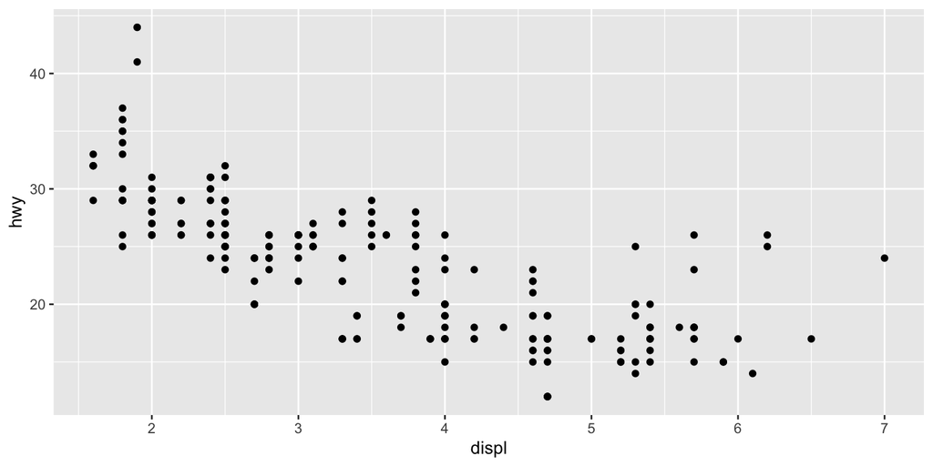

```r
ggplot(dataset, aes(x = displ, y = hwy)) +
  geom_point()
```

2. Change the code to map different variables to aesthetics: `model` and `manufacturer`

Is it useful? How could you modify the data to make it more informative?

3. Change the code to use a different `geom` - `geom_count`

Review the `ggplot2` cheatsheet in the VU Collaborate (you can also access it via your RStudio cloud account)

4. Review the following code to identify components, run the code by typing it yourself and change the code to use different mapping/geoms. Use ggplot2 cheatsheet to locate most suitable types of geoms.

```r
ggplot(mpg, aes(cty, hwy)) + geom_point()
ggplot(diamonds, aes(carat, price)) + geom_point()
ggplot(economics, aes(date, unemploy)) + geom_line()
ggplot(mpg, aes(cty)) + geom_histogram()
```

To add additional variables to a plot, we can use other aesthetics: - colour, - shape, and - size

These work in the same way as the x and y aesthetics, and are added into to `aes()`:

```r
aes(displ, hwy, colour = class)
aes(displ, hwy, shape = drv)
aes(displ, hwy, size = cyl)
```

Look the following example and replace the variable that you use to map in `colour`. Notice the type of variable that you can use:

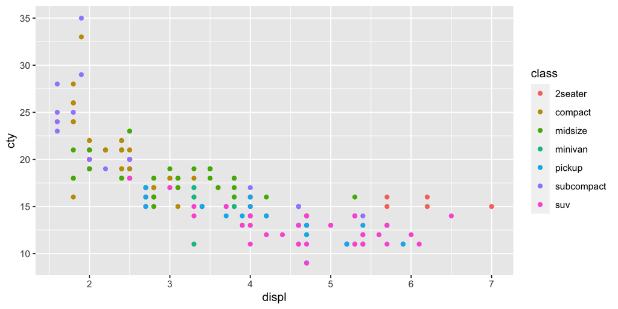

```r
ggplot(dataset, aes(displ, cty, colour = class)) +
  geom_point()
```

Compare the following plots and note the component to use for colour and the outcome:

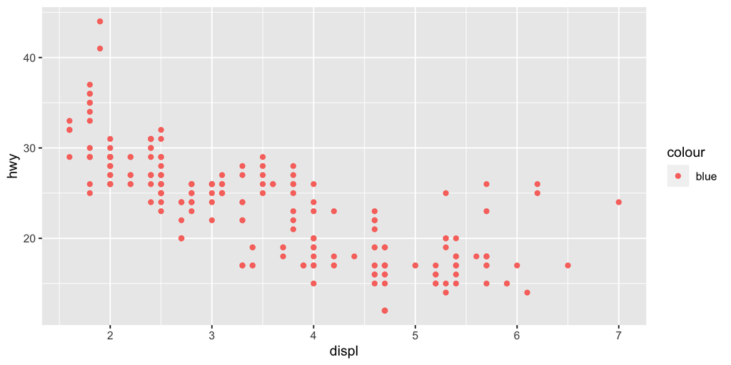

```r
ggplot(dataset, aes(displ, hwy)) + geom_point(aes(colour = "blue"))
```

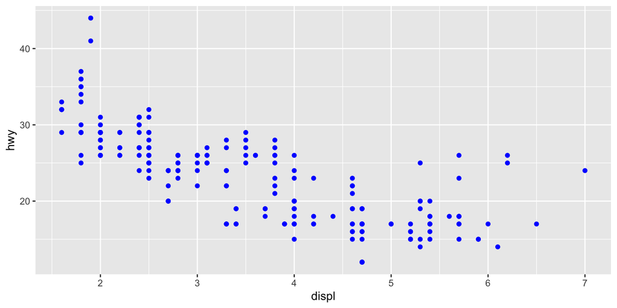

```r
ggplot(dataset, aes(displ, hwy)) + geom_point(colour = "blue")
```

**Important** - Colour and shape work well with categorical variables - Size works well for continuous variables. - if there is a lot of data it can be hard to distinguish different groups. - For the multiple groups use facetting

**Tasks**

- Experiment with the colour, shape and size aesthetics. What happens when you map them to continuous values? What about categorical values? What happens when you use more than one aesthetic in a plot?
- What happens if you map a continuous variable to shape? Why? What happens if you map trans to shape? Why?
- How is drive train related to fuel economy? How is drive train related to engine size and class?

#### Facetting

**Facetting** creates tables of graphics by splitting the data into subsets and displaying the same graph for each subset.

There are two types of facetting: - grid - wrapped - most useful

To facet a plot you simply add a facetting specification with `facet_wrap()`, which takes the name of a variable preceded by `~`.

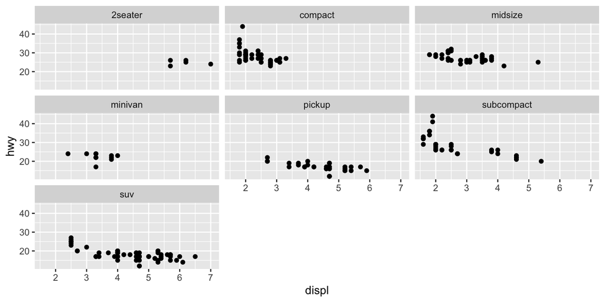

```r
ggplot(dataset, aes(displ, hwy)) +
  geom_point() +
  facet_wrap(~class)
```

**Tasks**

- What happens if you try to facet by a continuous variable like hwy? What about cyl? What’s the key difference?
- Use facetting to explore the 3-way relationship between fuel economy, engine size, and number of cylinders. How does facetting by number of cylinders change your assessement of the relationship between engine size and fuel economy?
- Read the documentation for facet_wrap(). What arguments can you use to control how many rows and columns appear in the output?
- What does the scales argument to facet_wrap() do? When might you use it?

### Plot geoms

You might guess that by substituting geom_point() for a different geom function, you’d get a different type of plot.

Main geoms:

- `geom_smooth()` fits a smoother to the data and displays the smooth and its standard error.
- `geom_boxplot()` produces a box-and-whisker plot to summarise the distribution of a set of points.
- `geom_histogram()` and `geom_freqpoly()` show the distribution of continuous variables.
- `geom_bar()` shows the distribution of categorical variables.
- `geom_path()` and `geom_line()` draw lines between the data points. A line plot is constrained to produce lines that travel from left to right, while paths can go in any direction. Lines are typically used to explore how things change over time.

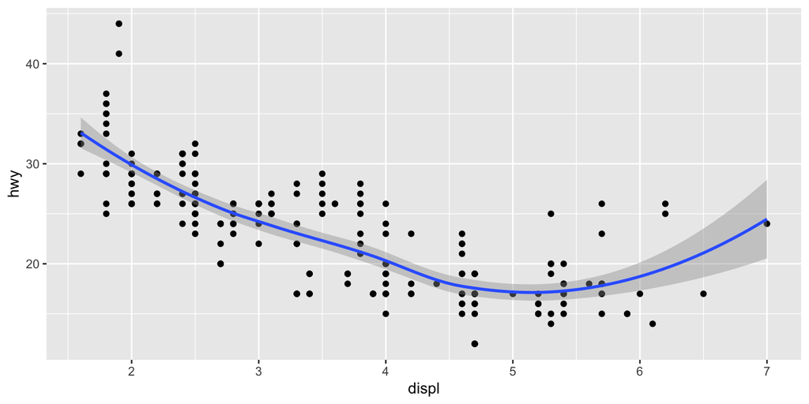

```r
ggplot((dataset), aes(displ, hwy)) +
  geom_point() +
  geom_smooth()
```

**Task**

- What’s the problem with the plot created by `ggplot(mpg, aes(cty, hwy)) + geom_point()`? Which of the geoms described above is most effective at remedying the problem?
- One challenge with `ggplot(mpg, aes(class, hwy)) + geom_boxplot()` is that the ordering of class is alphabetical, which is not terribly useful. How could you change the factor levels to be more informative?
- Rather than reordering the factor by hand, you can do it automatically based on the data: `ggplot(mpg, aes(reorder(class, hwy), hwy)) + geom_boxplot()`. What does `reorder()` do? Read the documentation.
- Explore the distribution of the carat variable in the `diamonds` dataset. What `binwidth` reveals the most interesting patterns?
- Explore the distribution of the price variable in the `diamonds` data. How does the distribution vary by cut?
- You now know (at least) three ways to compare the distributions of subgroups: `geom_violin()`, `geom_freqpoly()` and the `colour` aesthetic, or `geom_histogram()` and `facetting.` What are the strengths and weaknesses of each approach? What other approaches could you try?
- Read the documentation for `geom_bar()`. What does the `weight` aesthetic do?
- Using the techniques already discussed, come up with three ways to visualise a 2d categorical distribution. Try them out by visualising the distribution of `model` and `manufacturer`, `trans` and `class`, and `cyl` and `trans`

#### Modifying the axes

`xlab()` and `ylab()` modify the x- and y-axis labels:

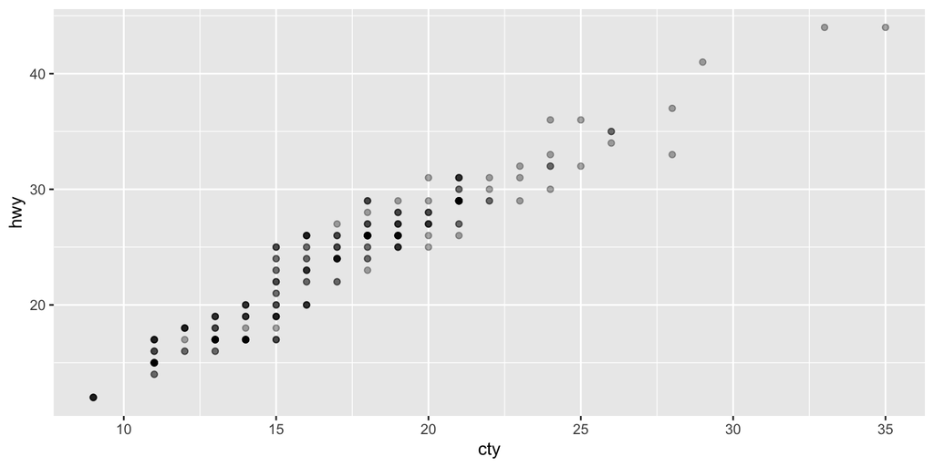

```r
ggplot(dataset, aes(cty, hwy)) +
  geom_point(alpha = 1 / 3)
```

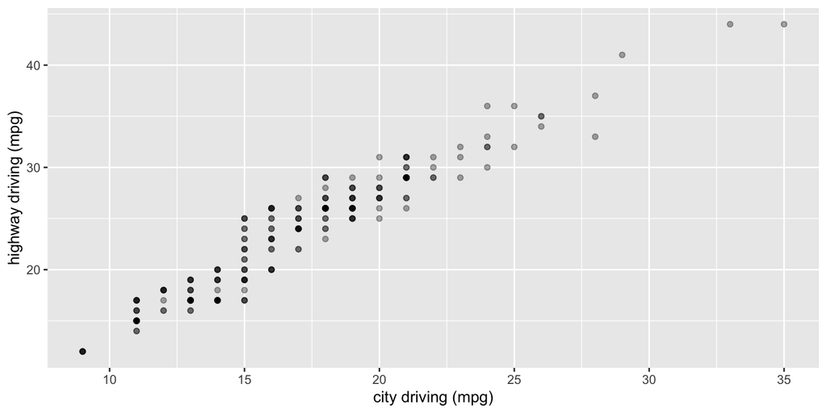

```r
ggplot(dataset, aes(cty, hwy)) +
  geom_point(alpha = 1 / 3) +
  xlab("city driving (mpg)") +
  ylab("highway driving (mpg)")
```

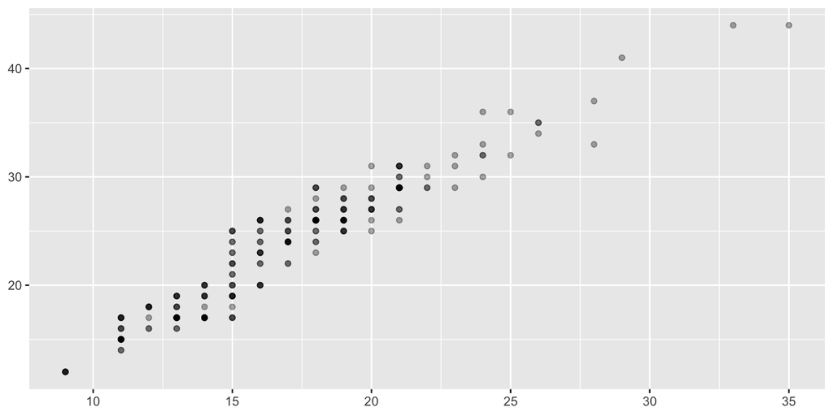

```r
# Remove the axis labels with NULL
ggplot(dataset, aes(cty, hwy)) +
  geom_point(alpha = 1 / 3) +
  xlab(NULL) +
  ylab(NULL)
```

`xlim()` and `ylim()` modify the limits of axes:

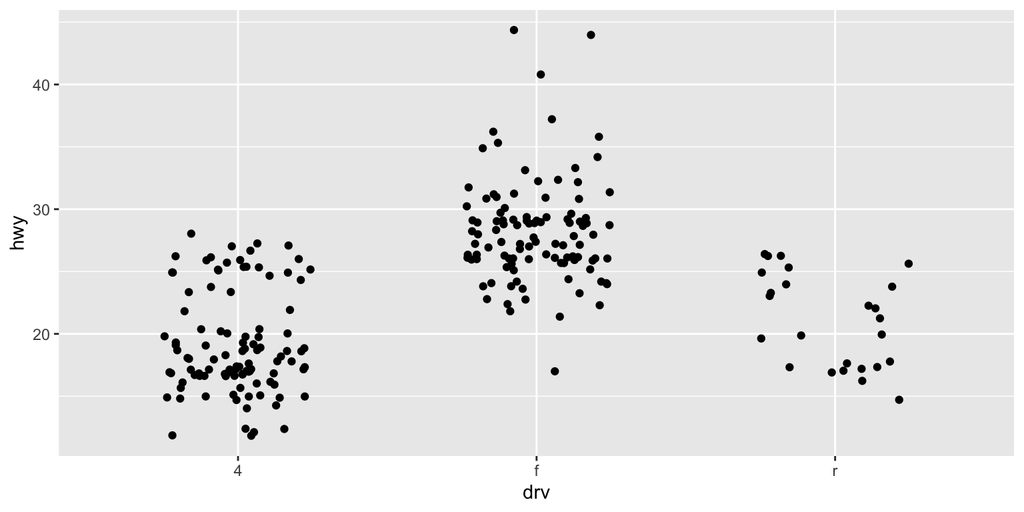

```r
ggplot(dataset, aes(drv, hwy)) +
  geom_jitter(width = 0.25)
```

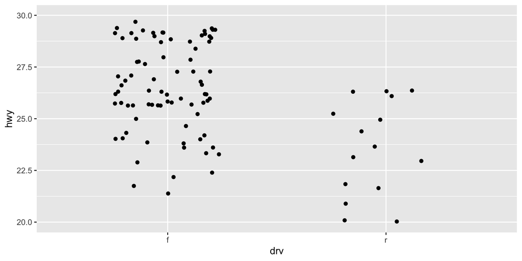

```r
ggplot(dataset, aes(drv, hwy)) +
  geom_jitter(width = 0.25) +
  xlim("f", "r") +
  ylim(20, 30)
```

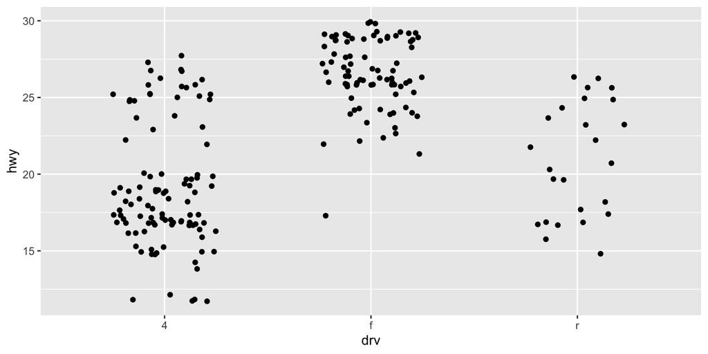

```r
# For continuous scales, use NA to set only one limit
ggplot(dataset, aes(drv, hwy)) +
  geom_jitter(width = 0.25, na.rm = TRUE) +
  ylim(NA, 30)
```

#### Themes

Main components:

- Theme **elements** specify the non-data elements that you can control, e.g

– `plot.title`: controls the appearance of the plot title; – `axis.ticks.x`: the ticks on the x axis; – `legend.key.height`: the height of the keys in the legend.

- Each element is associated with an **element function**, which describes the visual properties of the element,

– `element_text()`: sets the font size, colour and face of text elements like `plot.title`.

- The `theme()` function which allows you to override the default theme elements by calling element functions, like `theme(plot.title = element_text(colour = "red"))`.
- **Complete themes**, like `theme_grey()` set all of the theme elements to values designed to work together harmoniously.

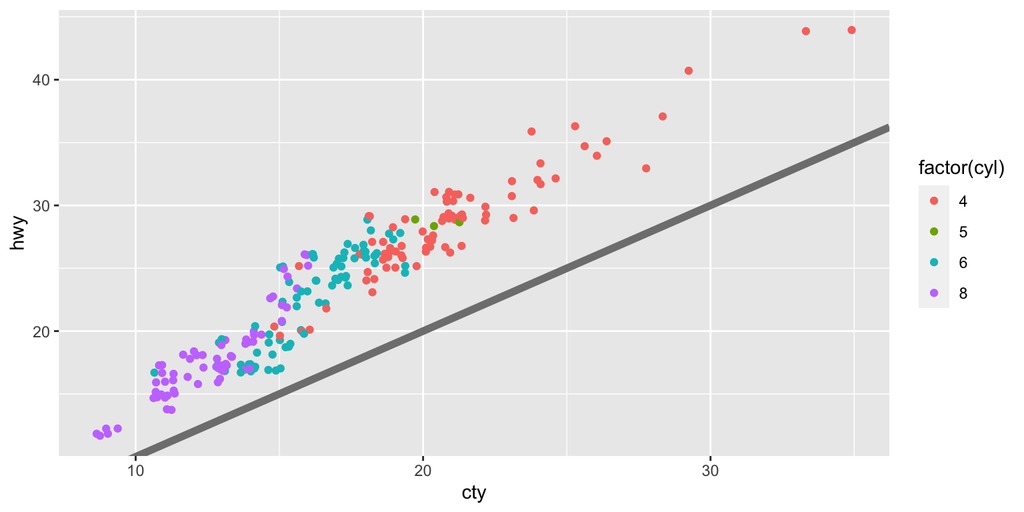

```r
base <- ggplot(dataset, aes(cty, hwy, color = factor(cyl))) +
  geom_jitter() +
  geom_abline(colour = "grey50", size = 2)
base
```

**Sample Solutions:**

ggplot(dataset, aes(model, manufacturer)) + geom_point()

ggplot(mpg, aes(model, manufacturer)) + geom_count()

ggplot(mpg, aes(cty, hwy)) + geom_point() ggplot(diamonds, aes(carat, price)) + geom_point() ggplot(economics, aes(date, unemploy)) + geom_line() ggplot(mpg, aes(cty)) + geom_histogram()